# Indeed Assignment - Rami Antoun

## 5/9/2016

#### Import libraries

```python
import pandas as pd
import numpy as np
import matplotlib.pyplot as plt
import seaborn as sns
```

#### Read in Data

```python
neiss = pd.read_csv("NEISS2014.csv")
body_parts = pd.read_csv("BodyParts.csv")
diag_codes = pd.read_csv("DiagnosisCodes.csv")
disp = pd.read_csv("Disposition.csv")
```

### Question 1

```python
# Quick check that each row is a unique case
len(np.unique(neiss["CPSC Case #"])) == len(neiss)

# Group by and and get count by case number
bparts_grp = neiss[['CPSC Case #','body_part']].groupby(by = 'body_part').count('CPSC Case #').reset_index()
bparts_grp.rename(columns = {'body_part': 'Code', 'CPSC Case #': 'Cases'}, inplace = True)

# Join with "body_parts" to get names
bparts_grp = bparts_grp.merge(body_parts, on = 'Code')
bparts_grp = bparts_grp[~bparts_grp.BodyPart.isin(['Not Recorded'])]
```

##### What are the top three body parts most frequently represented in this dataset?

```python
# Sort by case count descending
bparts_grp.sort('Cases', ascending = False)[['BodyPart','Cases']].head(3)
```

|  | BodyPart | Cases |
| --- | --- | --- |
| 10 | Head | 9891 |
| 11 | Face | 5786 |
| 23 | Finger | 5783 |

##### What are the top three body parts that are least frequently represented?

```python
# Sort by case count ascending
bparts_grp.sort('Cases', ascending = True)[['BodyPart','Cases']].head(3)
```

|  | BodyPart | Cases |
| --- | --- | --- |
| 18 | 25-50% of body | 4 |
| 9 | Pubic region | 286 |
| 0 | Internal | 549 |

For this analysis, I removed "Not Recorded" since it is not an actual body part. I should note that it was one of the 3 least frequently represented "body parts" in the data with 390 total unrecorded cases.

### Question 2

##### How many injuries in this dataset involve a skateboard?

Skateboards correspond to product 1333 per NEISS Coding Manual

```python
skate_inj = neiss[(neiss.prod1.isin([1333])) | neiss.prod2.isin([1333])]
print str(len(skate_inj)) + " Skateboard-related Injuries"
```

```
495 Skateboard-related Injuries
```

##### Of those injuries, what percentage were male and what percentage were female?

```python
skate_gender = skate_inj[['CPSC Case #','sex']].groupby('sex').count().reset_index()
skate_gender.rename(columns = {'CPSC Case #': 'Cases'}, inplace = True)
skate_gender['percentage'] = skate_gender['Cases'] / skate_gender['Cases'].sum()

# Format percentage in dataframe
skate_gender['percentage'] = skate_gender['percentage'].apply(lambda x: "{0:.2f}%".format(x * 100))
skate_gender.rename(columns = {'percentage': '% of Skateboard Injuries'}, inplace = True)
skate_gender[['sex', '% of Skateboard Injuries']]
```

|  | sex | % of Skateboard Injuries |
| --- | --- | --- |
| 0 | Female | 17.98% |
| 1 | Male | 82.02% |

##### What was the average age of someone injured in an incident involving a skateboard?

```python
avg_age = round(skate_inj['age'].mean(), 1)
print "The average age of someone injured in an incident involving a skateboard is {0} years old.".format(avg_age)
```

```
The average age of someone injured in an incident involving a skateboard is 17.9 years old.
```

### Question 3

##### What diagnosis had the highest hospitalization rate?

```python
# Join Disposition and Diagnosis Code tables into NEISS / Rename and remove unnecessary columns
neiss = neiss.merge(disp, left_on = 'disposition', right_on = 'Code')
neiss = neiss.merge(diag_codes, left_on = 'diag', right_on = 'Code')

neiss.rename(columns = { 'diag': 'diag_code', 'Diagnosis': 'diag_name',
                         'disposition': 'disp_code', 'Disposition': 'disp_name'}, inplace = True)
neiss.drop(['Code_x','Code_y'], axis=1, inplace = True)
```

```python
grp_diag = neiss[['diag_name','disp_code','CPSC Case #']].groupby(['diag_name','disp_code']).count().reset_index()
grp_diag.rename(columns = {'CPSC Case #': 'Cases'}, inplace = True)

diag_cases = grp_diag[['diag_name','Cases']].groupby('diag_name').sum().reset_index()
diag_cases.rename(columns = {'Cases': 'Total Cases'}, inplace = True)

grp_diag = grp_diag.merge(diag_cases, on = 'diag_name')
grp_diag['disp_rate'] = grp_diag['Cases'] / grp_diag['Total Cases']

grp_diag[grp_diag.disp_code == 4].sort('disp_rate', ascending = False).head(5)
```

|  | diag_name | disp_code | Cases | Total Cases | disp_rate |
| --- | --- | --- | --- | --- | --- |
| 128 | Submersion (including Drowning) | 4 | 23 | 54 | 0.425926 |
| 74 | Fracture | 4 | 1811 | 9735 | 0.186030 |
| 2 | Amputation | 4 | 20 | 125 | 0.160000 |
| 114 | Poisoning | 4 | 88 | 724 | 0.121547 |
| 94 | Internal organ injury | 4 | 630 | 5306 | 0.118734 |

##### What diagnosis most often concluded with the individual leaving without being seen?

```python
grp_diag[grp_diag.disp_code == 6].sort('disp_rate', ascending = False).head(5)
```

|  | diag_name | disp_code | Cases | Total Cases | disp_rate |
| --- | --- | --- | --- | --- | --- |
| 116 | Poisoning | 6 | 24 | 724 | 0.033149 |
| 110 | Other/Not Stated | 6 | 257 | 8120 | 0.031650 |
| 14 | Aspirated foreign object | 6 | 2 | 66 | 0.030303 |
| 28 | Burns, radiation (includes all cell damage by ... | 6 | 1 | 35 | 0.028571 |
| 23 | Burns, chemical (caustics, etc.) | 6 | 2 | 86 | 0.023256 |

##### Briefly discuss your findings and any caveats you'd mention when discussing this data

The diagnosis that had the highest hospitalization rate was Submersion, with 43% of patients with that diagnosis being hospitalized. However, there were only 54 total cases of Submersion diagnosed. Of the more common diagnoses, fractures resulted in the highest hospitalization rate at about 19%.

For the first part, I used the disposition code "Treated and admitted for hospitalization (within same facility)" in aggregating the data for this analysis. It should be noted that patients could have been transferred to another hospital and admitted there, but this dataset does not signal whether a patient was hospitalized in a different hospital.

### Question 4

##### Visualize any existing relationship between age and reported injuries

```python
%matplotlib inline
```

```python
# Define Function to create age groupings
def age_grp(x):

    if x >= 200:
        return "0-2"
    elif x >= 2 and x <= 5:
        return "2-5"
    elif x > 5 and x <= 10:
        return "6-10"
    elif x > 10 and x <= 16:
        return "10-16"
    elif x > 16 and x <= 25:
        return "16-25"
    elif x > 25 and x <= 35:
        return "25-35"
    elif x > 35 and x <= 50:
        return "35-50"
    elif x > 50 and x <= 65:
        return "50-65"
    elif x > 65:
        return "65+"

# Function to fix ages that show over 200 (which correspond to children under 2 years old, i.e. 220 = 20 month old)
def age_fix(x):

    if x >=200:
        return (x-200)/12
    else:
        return x
```

```python
# Apply functions to each row
neiss['age_group'] = neiss['age'].apply(age_grp)
neiss['age_fixed'] = neiss['age'].apply(age_fix)
```

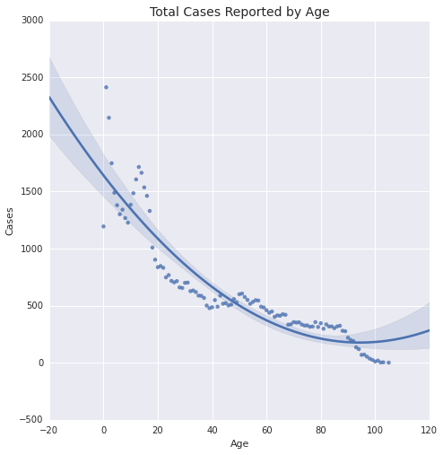

```python
# Group by age and plot
neiss_viz1 = neiss[['age_fixed','diag_name','CPSC Case #']].groupby(['age_fixed']).count().reset_index()
neiss_viz1.rename(columns = {'CPSC Case #': 'Cases'}, inplace = True)

sns.set_style('darkgrid')
sns.lmplot(x='age_fixed',y='Cases', order=2, data=neiss_viz1, size=7)
sns.plt.title('Total Cases Reported by Age', size=14)
sns.plt.xlabel('Age')
```

I first wanted to take a simple look at the number of cases by age (all diagnoses). This plot looks as I would expect - cases are highest at early ages and especially for kids under 5 where parents will tread carefully and bring their child to the doctor for even the most minor of injuries. As people continue to age, the visits to the doctor become less frequent through about the age of 50, when it's likely that with older age there will be more concern and a longer road to recovery with every new injury or accident.

I then looked a little more closely at reported injuries by age group for specific diagnoses (below).

```python
# Total Cases by age
age_cases = neiss[['age_group','CPSC Case #']].groupby(['age_group']).count().reset_index()
age_cases.rename(columns = {'CPSC Case #': 'Total Cases'}, inplace = True)
```

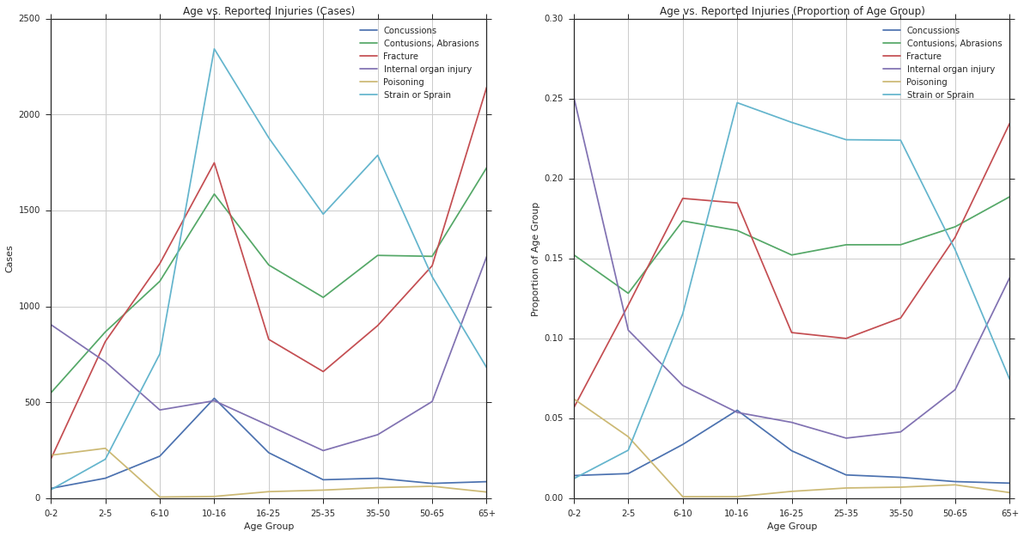

```python
# Group by age group and diagnosis
neiss_viz2 = neiss[['age_group','diag_name','CPSC Case #']].groupby(['age_group','diag_name']).count().reset_index()
neiss_viz2.rename(columns = {'CPSC Case #': 'Cases'}, inplace = True)

# Get the people in the age group with diagnosis as a proportion of all people in the age group
neiss_viz2 = neiss_viz2.merge(age_cases, on = 'age_group')
neiss_viz2['age_prop'] = neiss_viz2['Cases'] / neiss_viz2['Total Cases']

# Filter to only a few interesting diagnoses
neiss_viz2 = neiss_viz2[(neiss_viz2['diag_name'].isin(['Poisoning','Strain or Sprain','Internal organ injury',
                                        'Concussions','Contusions, Abrasions','Fracture']))]

# Order of age_groups on x-axis
ages = ['0-2','2-5','6-10','10-16','16-25','25-35','35-50','50-65','65+']
mapping = {age: i for i, age in enumerate(ages)}

# Plot settings
sns.set_style('whitegrid')
sns.set_style("ticks", {"xtick.major.size": 6, "ytick.major.size": 6})

for i, group in neiss_viz2.groupby('diag_name'):
    # Enforce ordering of age_groups on x-axis
    key = neiss_viz2['age_group'].map(mapping)
    group['index'] = group['age_group'].apply(lambda x: mapping[x])
    group.sort('index', inplace=True)

    plt.figure(2,figsize=(20,10))
    plt.subplot(121)
    group.plot(x='age_group', y='Cases', title='Age vs. Reported Injuries (Cases)', label = str(i))
    plt.xlabel('Age Group')
    plt.ylabel('Cases')
    plt.legend(loc='upper right')
    plt.subplot(122)
    group.plot(x='age_group', y='age_prop', title='Age vs. Reported Injuries (Proportion of Age Group)', label = str(i))
    plt.xlabel('Age Group')
    plt.ylabel('Proportion of Age Group')
    plt.legend(loc='upper right')
```

I created age groupings to help summarize the data and create for cleaner, less jagged plots. The plot on the left displays the number of cases reported within each age group for the chosen diagnoses. The plot on the right shows the proportion of all reported injuries within each age group that were for the chosen diagnoses.

I picked just a few of the diagnoses and had a couple of observations:

**Concussions**: Most frequently reported between the ages of 10-16, when kids are entering into more "violent" sports (i.e. football, wrestling, etc.) that could help explain that uptick.

**Strain or Sprain**: Again, this injury is most frequently seen between the ages of 10-16 with kids likely ramping up physical activity. However, we also see another spike later on in ages 35-50 where we may become more prone to strains/sprains. This could be due to a number of reasons like resuming physical activity after an extended period of time, or playing around with kids.

**Fracture**: Here we see a continuous increase in reported fractures until the age of 16 as we're growing into our bodies and partaking in more physical activity. Additionally, we see the peak of reported fractures at older ages of 65+ when our bones are weaker and even a light fall could cause a fracture.

### Question 5

##### Investigate the data however you like and discuss any interesting insights you can find in the data

I decided to look specifically at diagnosed fractures by body parts and by gender.

```python
# Join body parts to original dataset
neiss.rename(columns = {'body_part': 'body_part_code'}, inplace=True)
body_parts.rename(columns = {'Code': 'body_part_code'}, inplace=True)
neiss = neiss.merge(body_parts, on = 'body_part_code')

neiss['age_bp_group'] = neiss['age_fixed'].apply(age_bp)
```

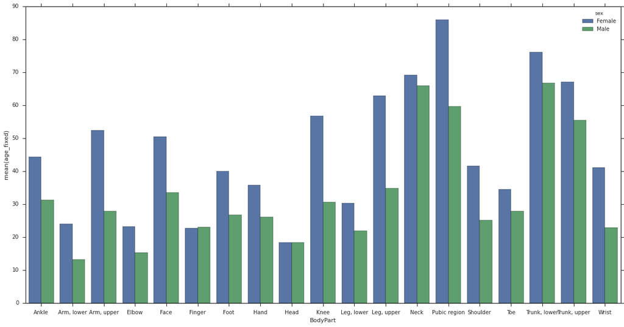

```python
# Exclude 'Not Recorded' diagnosis
fractures = neiss[(neiss.diag_name == 'Fracture') & (neiss.BodyPart != 'Not Recorded')].reset_index()
fract_age = fractures[['BodyPart','sex','age_fixed']].groupby(['BodyPart','sex']).mean().reset_index()

plt.figure(figsize=(20,10))
ax = sns.barplot(x='BodyPart', y='age_fixed', hue='sex', data=fract_age)
```

I wanted to look further into the data to see how members of each sex suffered their fractures. I decided to perform some relatively simple text analysis to find some of the most common words/themes among male fractures relative to female fractures and vice versa.

#### Text Preprocessing

```python
from nltk.corpus import stopwords
from string import punctuation
from sklearn.feature_extraction.text import CountVectorizer
from nltk.classify import NaiveBayesClassifier
import random
```

Here I'm performing some **text preprocessing** to remove words and punctuation that I do not want to be included in the analysis.

```python
# Remove common 'stopwords' from narrative
stop = stopwords.words('english')

# Function to remove punctuation from text
def strip_punctuation(s):
    return ''.join(c for c in s if c not in punctuation)

# Apply functions to narratives and return in new column
fractures['narrative_clean'] = fractures['narrative'].apply(strip_punctuation)
fractures['narrative_clean'] = fractures['narrative_clean'].apply(lambda x: [word for word in x.lower().split() if word not in stop])
fractures['narrative_clean'] = fractures['narrative_clean'].apply(lambda x: ' '.join(x))
```

I sampled 1000 narratives evenly from Male and Female fractures to cut down running time and to minimize skewing in the dataset (i.e. too many narratives from knee fractures).

```python
m_fract = fractures[fractures['sex'] == 'Male']
f_fract = fractures[fractures['sex'] == 'Female']

m_rows = random.sample(m_fract.index, 500)
f_rows = random.sample(f_fract.index, 500)

m_train = m_fract.ix[m_rows]
f_train = f_fract.ix[f_rows]

# Create dataframe with 1000 sampled reviews
fractures_train = pd.concat([m_train,f_train], ignore_index=True)

# Create tuples to assign each narrative to the associated sex
frac_narratives = [(fractures_train['narrative_clean'][i], fractures_train['sex'][i])
               for i in range(len(fractures_train))]
```

#### Word Counts by Sex and Naive Bayes Classifier

Below, I use a CountVectorizer to grab feature (word) counts as seen in the the narratives. I also tell the CountVectorizer to keep **separate** counts of each word as seen in Male fractures and Female fractures.

I then ran a Naive Bayes Classifier. This is a classifier I have used in text analysis in the past where the benefits are primarily the performance speed and ease of reading results. As you can see, it computes and provides an output of ratios of words seen in Male fracture narratives against Female fracture narratives.

```python
# Use CountVectorizer to extract features (words) from narratives
vectorizer = CountVectorizer(min_df=1)
X_train = vectorizer.fit_transform(fractures_train['narrative_clean'].tolist())

t = [({str(word): (word in x[0])
       for word in vectorizer.get_feature_names()}, x[1]) for x in frac_narratives[:1000]]
```

#### Results

```python
# Train Naive Bayes Classifier and show "most informative" words
nb_classifier = NaiveBayesClassifier.train(t)
nb_classifier.show_most_informative_features(20)
```

```
Most Informative Features
                    room = True           Female : Male   =     11.7 : 1.0
                bathroom = True           Female : Male   =      9.0 : 1.0
                     bat = True           Female : Male   =      8.2 : 1.0
                  basket = True             Male : Female =      7.9 : 1.0
              basketball = True             Male : Female =      7.8 : 1.0
                     get = True           Female : Male   =      7.3 : 1.0
                      85 = True           Female : Male   =      7.0 : 1.0
                      61 = True           Female : Male   =      7.0 : 1.0
                     wet = True           Female : Male   =      7.0 : 1.0
                  missed = True           Female : Male   =      7.0 : 1.0
                football = True             Male : Female =      6.8 : 1.0
                    bath = True           Female : Male   =      6.6 : 1.0
                 punched = True             Male : Female =      6.2 : 1.0
                      17 = True             Male : Female =      5.8 : 1.0
                 nursing = True           Female : Male   =      5.8 : 1.0
                     fem = True           Female : Male   =      5.8 : 1.0
                    eral = True           Female : Male   =      5.0 : 1.0
                    miss = True           Female : Male   =      5.0 : 1.0
                 playing = True             Male : Female =      4.6 : 1.0
                  helmet = True             Male : Female =      4.6 : 1.0
```

Firstly, I could have possibly improved the results with better text preprocessing - particularly by removing all numbers. However, the numbers that are shown here support what we see in the initial histogram I created for this question. The numbers **85** and **61** are seen in female fracture narratives 7 times more frequently than seen in male fracture narratives. Similarly, **17** is seen in male fracture narratives nearly 6 times more frequently than seen in female fracture narratives.

More interestingly, I like seeing that the other features extracted in this analysis confirm my assumptions in how males and females suffered their fractures on a relative basis. With words like **helmet, basketball, football, punched, playing**, we see that males suffer their fractures far more frequently playing sports or fighting than women do.

For females, we see **bathroom, wet, nursing, missed** as key features extracted that were mentioned in their fracture narratives as compared to being mentioned in male fracture narratives.

```python
!ipython nbconvert IndeedAssignment_RamiAntoun.ipynb --to html
```

```
[NbConvertApp] Converting notebook IndeedAssignment_RamiAntoun.ipynb to html
[NbConvertApp] Writing 536243 bytes to IndeedAssignment_RamiAntoun.html
```